# San Joaquin River

Sadie Gill, Mark Tompkins

July 2020

## Future Data Improvements

None planned.

## Instream Spawning and Rearing Habiat

**Data Source:** [Final Lower Tuolumne Instream Flow Study Report](https://s3-us-west-2.amazonaws.com/cvpiahabitat-r-package/cvpia-sit-model-inputs/Stillwater2010_Tuolumne_P-2299-075_71_DP_FLA_AttC_StudyRept_IFIM_AppA-H_140428.pdf) (pg. 108-109) and [Stanislaus Aceituno 1993](https://cvpiahabitat-r-package.s3-us-west-2.amazonaws.com/cvpia-sit-model-inputs/Aceituno1993_StanislausRiverIFIMStudy.pdf) (pg 19) and [Stanislaus FWS 2012](https://cvpiahabitat-r-package.s3-us-west-2.amazonaws.com/cvpia-sit-model-inputs/CVPIA_Annual_Progress_Report_Fiscal_Year_2012.pdf) (pg 6) and [Merced ID 2013](https://cvpiahabitat-r-package.s3-us-west-2.amazonaws.com/cvpia-sit-model-inputs/MID2013_MercedIFIMStudy.pdf) (pg 67-75)

There were no watershed specific salmonid habitat data available for the San Joaquin River. A regional weighted usable area (WUA) relationship with flow was derived for the San Joaquin River by averaging the WUA values on the three tributaries of the San Joaquin. Spawning and rearing data from the Merced, Stanislaus, and Tuolumne Rivers were used to estimate the spawning and rearing WUA for the San Joaquin. The data for these three tributaries were provided by Mark Gard from the California Department of Fish and Wildlife in a [spreadsheet](https://cvpiahabitat-r-package.s3-us-west-2.amazonaws.com/IFIMWUA.xlsx). Mark Gard instructed us to use A18:E48 of the ‘Merced’ tab, I4:N60 of the ‘Stanislaus’ tab, and A2:H32 in the ‘Tuolumne’ tab within the ‘IFIMWUA.xlsx’ spreadsheet.

### Combine Spawning and Rearing Data

The instream spawning and rearing habitat data described above for Fall Run Chinook Salmon (FR) are combined for use in the Decision Support Model (DSM) in the following format. Units are in square feet per 1000 feet.

Header Descriptions: flow_cfs = flow in cubic feet per second, FR_spawn_wua = Fall Run Chinook Spawning WUA, FR_fry_wua = Fall Run Chinook Fry WUA, FR_juv_wua = Fall Run Chinook Juvenile WUA, watershed = section of stream modeled for CVPIA SDM

| flow_cfs | FR_spawn_wua | FR_fry_wua | FR_juv_wua | watershed |
| --- | --- | --- | --- | --- |
| 25 | 3148.561 | 20750.38 | 27933.36 | San Joaquin River |
| 50 | 3616.241 | 20750.38 | 27933.36 | San Joaquin River |
| 100 | 7182.237 | 19029.26 | 29313.82 | San Joaquin River |
| 150 | 10833.961 | 17160.19 | 29733.33 | San Joaquin River |
| 200 | 13081.071 | 15670.93 | 28839.95 | San Joaquin River |

*… with 42 more rows*

### Spawning WUA

The following plot shows the spawning WUA in square feet per thousand feet for Fall Run Chinook Salmon. These area per length rates are multiplied by the total spawning reach length mapped by the Science Integration Team (SIT) to estimate available habitat.

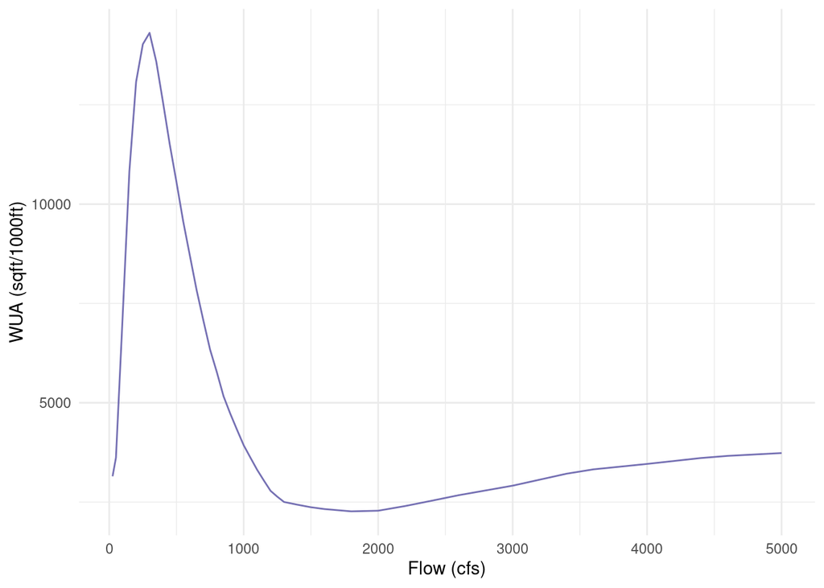

### Rearing WUA

The following plot shows the rearing WUA in square feet per thousand feet for Fall Run Chinook Salmon fry and juvenile. These rates are multiplied by the total rearing reach length mapped by the SIT to estimate available habitat.

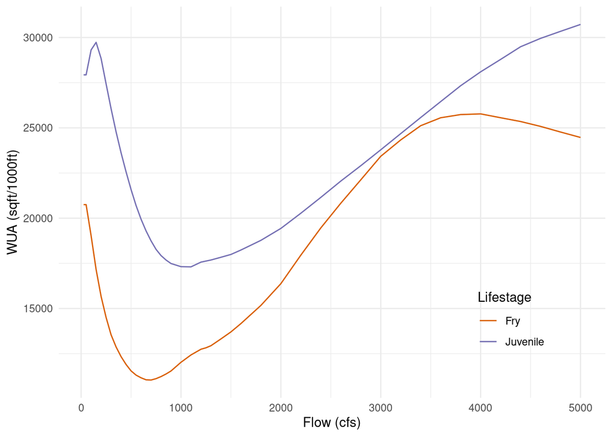

## Floodplain Rearing Habitat

**Data Source:** [Central Valley Floodplain Evaluation and Delineation (CVFED) HEC-RAS hydraulic model](https://s3-us-west-2.amazonaws.com/cvpiahabitat-r-package/cvpia-sit-model-inputs/TO25-ST8_Tech_Memo_SJR.pdf)

The entire mapped rearing extent of 45.7 miles was modeled using Central Valley Floodplain Evaluation and Delineation (CVFED) HEC-RAS hydraulic model. An active channel area of 534.2 acres, estimated through remote sensing analysis, was subtracted from total inundated area to obtain inundated floodplain area.

## Floodplain Data

The areas represent total inundated area in acres.

Header Descriptions: flow_cfs = flow in cubic feet per second, FR_floodplain_acres = Fall Run Chinook floodplain acres, SR_floodplain_acres = Spring Run Chinook floodplain acres, ST_floodplain_acres = Steelhead floodplain acres, watershed = section of stream modeled for CVPIA SDM

| flow_cfs | FR_floodplain_acres | SR_floodplain_acres | ST_floodplain_acres | watershed |
| --- | --- | --- | --- | --- |
| 770 | 0.0000 | 0.0000 | 0.0000 | San Joaquin River |
| 1520 | 94.4063 | 94.4063 | 94.4063 | San Joaquin River |
| 2214 | 279.4574 | 279.4574 | 279.4574 | San Joaquin River |
| 2270 | 294.3895 | 294.3895 | 294.3895 | San Joaquin River |
| 3020 | 702.2399 | 702.2399 | 702.2399 | San Joaquin River |

*… with 26 more rows*

## Floodplain Plot

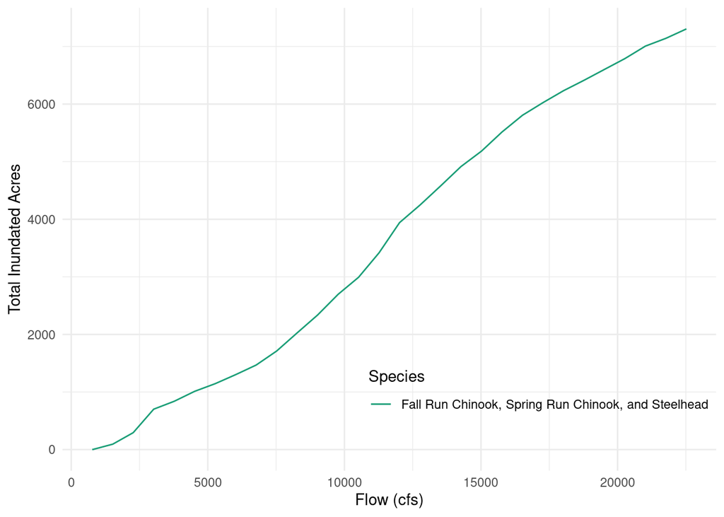